# [과제11] 모집단이 두 개인 경우 (독립표본, 대응표본) + 모집단이 세 개인 경우 (ANOVA, 적합도/독립성 검정)

### **문제 2**

#### MASS 패키지에 내장된 Cars93 데이터프레임에 대해서 생산국(Origin)이 USA vs. non-USA 2개의 group 에 대해서 차 가격(Price)의 평균이 차이가 있는지를 검정해보시오.

```r
library(MASS)
str(Cars93)
```

```
## 'data.frame':    93 obs. of  27 variables:
##  $ Manufacturer      : Factor w/ 32 levels "Acura","Audi",..: 1 1 2 2 3 4 4 4 4 5 ...
##  $ Model             : Factor w/ 93 levels "100","190E","240",..: 49 56 9 1 6 24 54 74 73 35 ...
##  $ Type              : Factor w/ 6 levels "Compact","Large",..: 4 3 1 3 3 3 2 2 3 2 ...
##  $ Min.Price         : num  12.9 29.2 25.9 30.8 23.7 14.2 19.9 22.6 26.3 33 ...
##  $ Price             : num  15.9 33.9 29.1 37.7 30 15.7 20.8 23.7 26.3 34.7 ...
##  $ Max.Price         : num  18.8 38.7 32.3 44.6 36.2 17.3 21.7 24.9 26.3 36.3 ...
##  $ MPG.city          : int  25 18 20 19 22 22 19 16 19 16 ...
##  $ MPG.highway       : int  31 25 26 26 30 31 28 25 27 25 ...
##  $ AirBags           : Factor w/ 3 levels "Driver & Passenger",..: 3 1 2 1 2 2 2 2 2 2 ...
##  $ DriveTrain        : Factor w/ 3 levels "4WD","Front",..: 2 2 2 2 3 2 2 3 2 2 ...
##  $ Cylinders         : Factor w/ 6 levels "3","4","5","6",..: 2 4 4 4 2 2 4 4 4 5 ...
##  $ EngineSize        : num  1.8 3.2 2.8 2.8 3.5 2.2 3.8 5.7 3.8 4.9 ...
##  $ Horsepower        : int  140 200 172 172 208 110 170 180 170 200 ...
##  $ RPM               : int  6300 5500 5500 5500 5700 5200 4800 4000 4800 4100 ...
##  $ Rev.per.mile      : int  2890 2335 2280 2535 2545 2565 1570 1320 1690 1510 ...
##  $ Man.trans.avail   : Factor w/ 2 levels "No","Yes": 2 2 2 2 2 1 1 1 1 1 ...
##  $ Fuel.tank.capacity: num  13.2 18 16.9 21.1 21.1 16.4 18 23 18.8 18 ...
##  $ Passengers        : int  5 5 5 6 4 6 6 6 5 6 ...
##  $ Length            : int  177 195 180 193 186 189 200 216 198 206 ...
##  $ Wheelbase         : int  102 115 102 106 109 105 111 116 108 114 ...
##  $ Width             : int  68 71 67 70 69 69 74 78 73 73 ...
##  $ Turn.circle       : int  37 38 37 37 39 41 42 45 41 43 ...
##  $ Rear.seat.room    : num  26.5 30 28 31 27 28 30.5 30.5 26.5 35 ...
##  $ Luggage.room      : int  11 15 14 17 13 16 17 21 14 18 ...
##  $ Weight            : int  2705 3560 3375 3405 3640 2880 3470 4105 3495 3620 ...
##  $ Origin            : Factor w/ 2 levels "USA","non-USA": 2 2 2 2 2 1 1 1 1 1 ...
##  $ Make              : Factor w/ 93 levels "Acura Integra",..: 1 2 4 3 5 6 7 9 8 10 ...
```

```
##
##  Shapiro-Wilk normality test
##
## data:  USA$Price
## W = 0.88411, p-value = 0.0002006
```

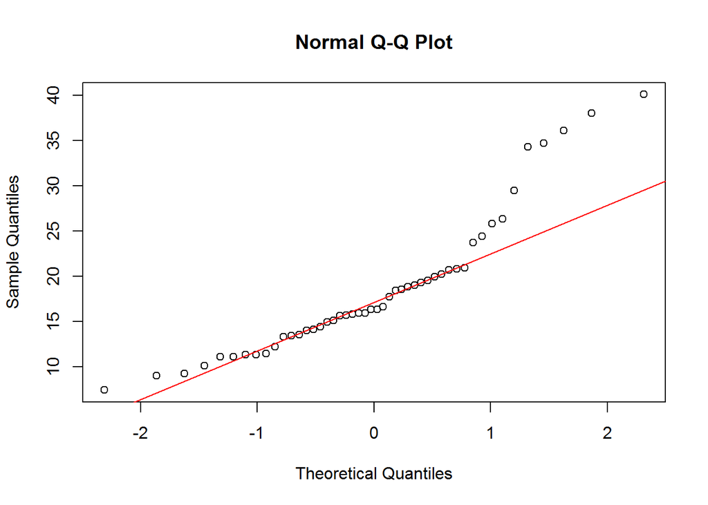

```r
# 0. 정규성 및 등분산성 검정

USA <- dplyr::select(Cars93, Origin, Price) %>% filter(Origin == "USA")
n_USA <- dplyr::select(Cars93, Origin, Price) %>% filter(Origin == "non-USA")

shapiro.test(USA$Price); qqnorm(USA$Price); qqline(USA$Price, col="red")       # p = 0.0002로 정규성을 만족하지 않음 -> 비모수검정
```

```
##
##  Shapiro-Wilk normality test
##
## data:  n_USA$Price
## W = 0.87756, p-value = 0.0002036
```

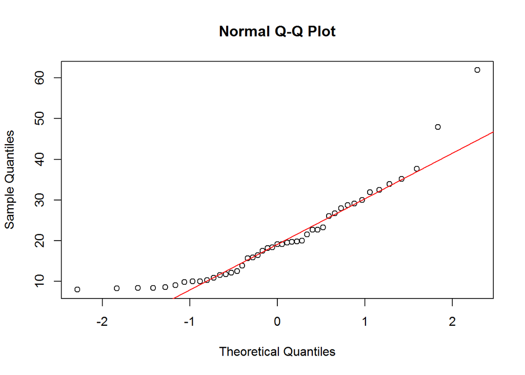

```r
shapiro.test(n_USA$Price); qqnorm(n_USA$Price); qqline(n_USA$Price, col="red") # p = 0.0002로 정규성을 만족하지 않음
```

### **비모수적 통계검정 (Wilcox rank test)**

#### 두 집단 모두 정규성을 따르지 않으므로 소속집단에 상관없이 크기순으로 나열 후 순위를 합한 다음 통계량을 계산하여 검정하는 대표적인 비모수적 방법으로 검정해본다.

```r
# 1. 가설검정

# H0 : 지역(Origin)별 차 가격(Price)의 평균이 차이가 없다
# H1 : 지역(Origin)별 차 가격(Price)의 평균이 차이가 있다 (양측)

wilcox.test(Cars93$Price ~ Cars93$Origin)
```

```
##
##  Wilcoxon rank sum test with continuity correction
##
## data:  Cars93$Price by Cars93$Origin
## W = 1024.5, p-value = 0.6724
## alternative hypothesis: true location shift is not equal to 0
```

```r
# 검정결과, p-value가 0.6724로 유의수준 5%에서 귀무가설을 기각할 충분한 근거가 없다. 즉, 지역에 따른 차 가격의 평균은 차이가 없다고 판단된다.
```